# Domestic Terrorist Web Network

Robert Gal

2025-07-13

**Introduction:** This project focuses on analyzing the relationships between websites affiliated with domestic terrorist groups in the United States. Each node represents a website, and a directed edge from one website to another indicating a hyperlink connection. The purpose of this visualization is to uncover patterns of influence, cohesion, and brokerage within the network, identifying which websites serve as central hubs, which are isolated, and whether tightly connected subgroups, cliques are present.

The dataset captured: https://sites.google.com/site/ucinetsoftware/datasets/covert-networks/domestic-terrorist-web-links

The project will use ’Domestic Terrorist Web Links’dataset. It is a directed 1-mode adjacency matrix network, which consist of hyperlinks between websites connected to domestic terrorist groups in the United States. The dataset consists of 32 rows and 32 columns, forming a 32 x 32 matrix. Each row and column represent a website, and the binary cell values indicate whether a hyperlink present, 1 if there is a link, 0 if there is no link between them

```r
library(igraph)
library(visNetwork)
library(tidygraph)
library(ggraph)
```

```r
setwd("C:/Users/Gigaboly/Desktop/PSU 2025/INSC 846")
crimeset <- read.csv("DOMESTICTERRORWEB.csv", header = TRUE, row.names = 1)
```

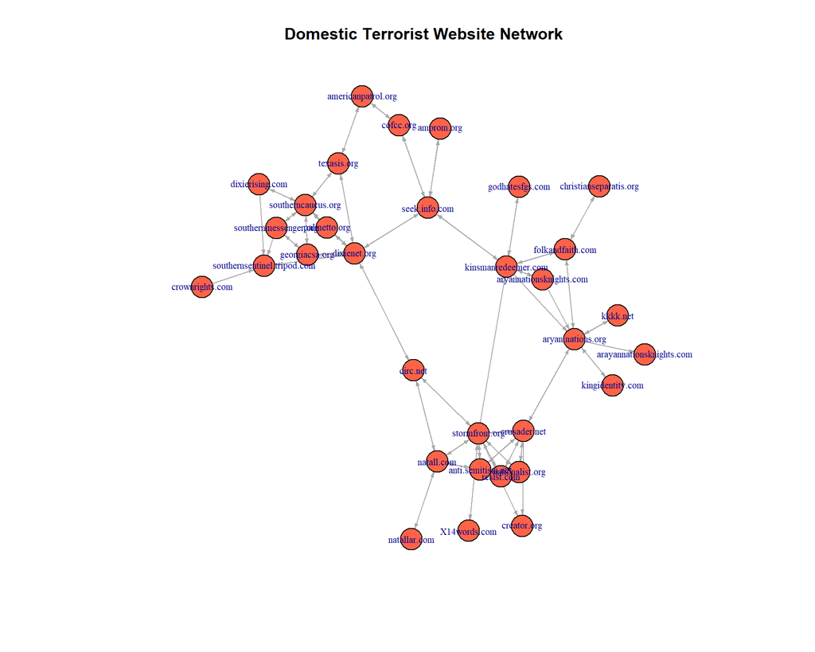

```r
#Plot the dataset:
crime_matrix <- as.matrix(crimeset)
g <- graph_from_adjacency_matrix(crime_matrix, mode = "directed", diag = FALSE)
plot(g,
     vertex.label = V(g)$name,
     vertex.color = "tomato",
     vertex.size = 10,
     vertex.label.cex = 0.7,
     edge.arrow.size = 0.3,
     layout = layout_with_fr(g),
     main = "Domestic Terrorist Website Network")
```

```r
# Get the number of rows and columns
dim(crimeset)
```

```
## [1] 32 32
```

```r
colnames(crimeset)
```

```
##  [1] "X14words.com"                "americanpatrol.org"
##  [3] "amprom.org"                  "anti.semitism.net"
##  [5] "arayannationsknights.com"    "aryan.nations.org"
##  [7] "aryannationsknights.com"     "christianseparatis.org"
##  [9] "circ.net"                    "cofcc.org"
## [11] "creator.org"                 "crownrights.com"
## [13] "crusader.net"                "dixienet.org"
## [15] "dixierising.com"             "folkandfaith.com"
## [17] "georgiacsa.org"              "godhatesfgs.com"
## [19] "kingidentity.com"            "kinsmanredeemer.com"
## [21] "kkkk.net"                    "natall.com"
## [23] "natallar.com"                "nationalist.org"
## [25] "palmetto.org"                "resist.com"
## [27] "seek.info.com"               "southerncaucus.org"
## [29] "southernmessenger.org"       "southernsentinel.tripod.com"
## [31] "stormfront.org"              "texasis.org"
```

**1. Which nodes are the most connected in the network?**

```r
avg_path_length <- average.path.length(g, directed = TRUE)
net_diameter <- diameter(g, directed = TRUE)
print(paste("Average Path Length:", round(avg_path_length, 2)))
```

```
## [1] "Average Path Length: 3.23"
```

```r
print(paste("Network Diameter:", net_diameter))
```

```
## [1] "Network Diameter: 7"
```

```r
# Calculate degree
deg <- degree(g, mode = "all")
# Make nodes for visNetwork
nodes <- data.frame(id = V(g)$name,
                    label = V(g)$name,
                    value = deg,
                    title = paste("Degree:", deg),
                    color = "tomato",
                    font.size = 24)

edges <- as_data_frame(g, what = "edges")
# Plot network
visNetwork(nodes, edges, main = "Network Topography") %>%
  visIgraphLayout(layout = "layout_with_fr") %>%
  visOptions(highlightNearest = TRUE, nodesIdSelection = TRUE)
```

[interactive chart not shown]

**Visual 1:** This visual shows the number of connections using the size. The node size encodes degree, so we can visually spot which websites (nodes) have more direct hyperlinks. Using visNetwork helps to explore degrees and relationships.

**2. Are there tightly connected groups of websites that consistently link to each other?**

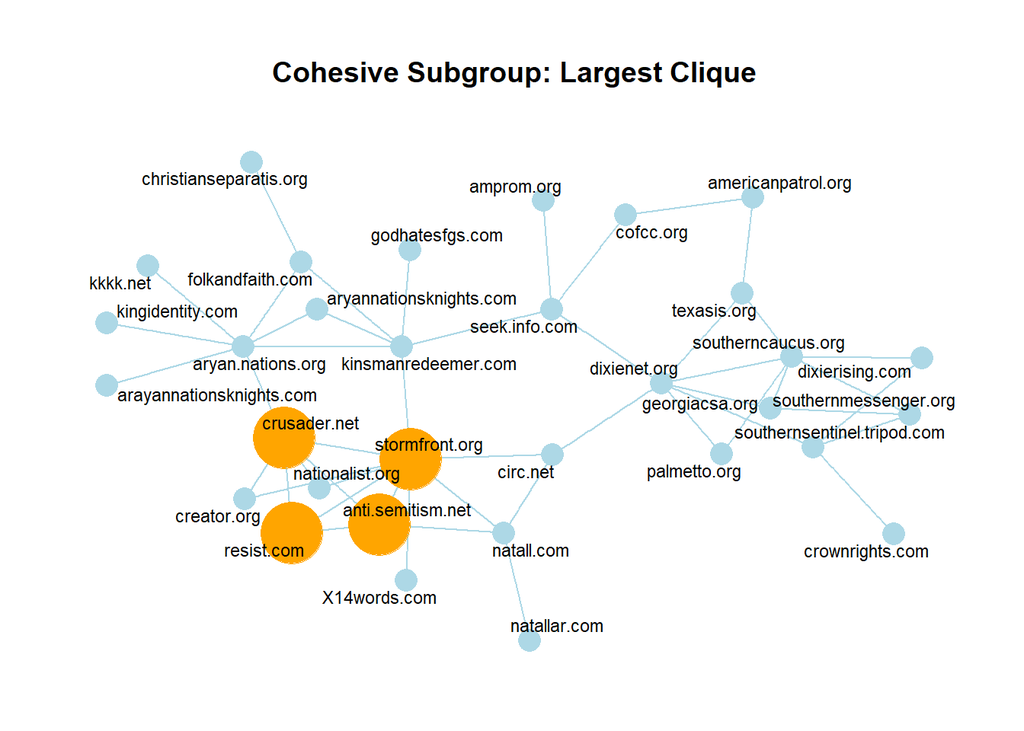

```r
# Convert to tidygraph object
library(tidygraph)
g_tbl <- as_tbl_graph(g)

# Find the largest clique
largest_clique <- largest.cliques(g)[[1]]

# Mark clique membership
g_tbl <- g_tbl %>%
  mutate(clique_member = ifelse(name %in% V(g)[largest_clique]$name, "Yes", "No"))

# Plot ggraph
ggraph(g_tbl, layout = "stress") +
  geom_edge_link(alpha = 1.5, color = "lightblue") +
  geom_node_point(aes(color = clique_member, size = clique_member), show.legend = FALSE) +
  geom_node_text(aes(label = name), repel = TRUE, size = 3) +
  scale_color_manual(values = c("Yes" = "orange", "No" = "lightblue")) +
  scale_size_manual(values = c("Yes" = 14, "No" = 5)) +
  labs(title = "Cohesive Subgroup: Largest Clique\n") +
  theme_graph(base_family = "sans") +
  theme(plot.title = element_text(size = 14, hjust = 0.5)
)
```

**Visual 2:** The graph identifies and visualizes the largest cohesive subgroup in the network. These 4 nodes form a fully connected group, where each of those 4 websites links directly to every other in that group. This is the largest completely cohesive subgroup in the network.

**3. Which website is the most influential broker connecting different groups in the network?**

```r
# Calculate betweenness
btwn <- betweenness(g, directed = TRUE)

# Scale node sizes
V(g)$size <- (btwn / max(btwn)) * 30 + 5
# Create color nodes
V(g)$color <- ifelse(btwn == max(btwn), "red", "tan")

# Create nodes for visNetwork
nodes <- data.frame(id = V(g)$name,
                    label = V(g)$name,
                    color = V(g)$color,
                    size = V(g)$size)

# Create edges for visNetwork
edges <- as_data_frame(g, what = "edges")
colnames(edges)[1:2] <- c("from", "to")

# Print title
cat("Central Actor: Highest Betweenness\n")
```

```
## Central Actor: Highest Betweenness
```

```r
# Plot visnetwork
visNetwork(nodes, edges, main = "Central Actor: Highest Betweenness",
           width = "100%", height = "800px") %>%
  visEdges(color = list(color = "tan")) %>%
  visNodes(borderWidth = 15, font = list(size = 20)) %>%
  visLayout(randomSeed = 42) %>%
  visPhysics(stabilization = TRUE)
```

[interactive chart not shown]

**Visual 3:** This plot identifies the “broker” websites that connect different parts of the network. The red node is the most influential broker, controlling many paths between others. Larger nodes are the more influential ones. This network visualization uses betweenness centrality to identify key brokers within the network. Node size represents brokerage influence, and the red node highlights the website with the highest betweenness centrality, meaning it acts as the most important intermediary connecting different parts of the network.

**Summary:** Overall, these three network visualizations revealed important insights into the domestic terrorist web network. Some websites are more connected than others, dixinet.org happened to be the most connected node in the network. A tightly linked group forms a clique, with 4 websites fully connected to one another. Additionally, dixinet.org also stands out as the most influential broker, with the highest betweenness centrality, suggesting it plays the main role in connecting all websites and functioning as key hub within the terrorist network.

References:

https://sites.google.com/site/ucinetsoftware/datasets/covert-networks/domestic-terrorist-web-links https://psu.instructure.com/courses/2414988/modules/items/44381109